# Not Falling Short

Injury Epidemiology of Falls in Iowa

Nicolas Foss, Ed.D., MS

2025-09-26

# Objectives

Today we will look at…

- injury data where injuries occurred in Iowa
- overall statistics on falls
- the distribution of falls across:
  - geographic areas
  - demographic groups
- fall patient outcomes

# Accessing this presentation

- [Bureau of Emergency Medical and Trauma Services GitHub Page](https://github.com/bemts-hhs/)
- [`{traumar}` package page](https://bemts-hhs.github.io/traumar/)

# About the data

Source: Iowa Trauma Registry from 2020-2024.

- Check out [Trauma Data Registry](https://hhs.iowa.gov/health-prevention/providers-professionals/emergency-medical-services-trauma/trauma-system-resources/trauma-data-registry) for inclusion criteria.
- The trauma registry…
  - …houses data on the most severe injuries.
  - …does not register all injuries in Iowa.
    - Iowa Hospital Association’s Inpatient Outpatient dataset = comprehensive

# Overall fall statistics

In the following slides, we will review state-level fall statistics.

## Falls at a glance

Year over year, since 2020, falls make up > 55% of all injury events in Iowa. Same-level falls grow rapidly.

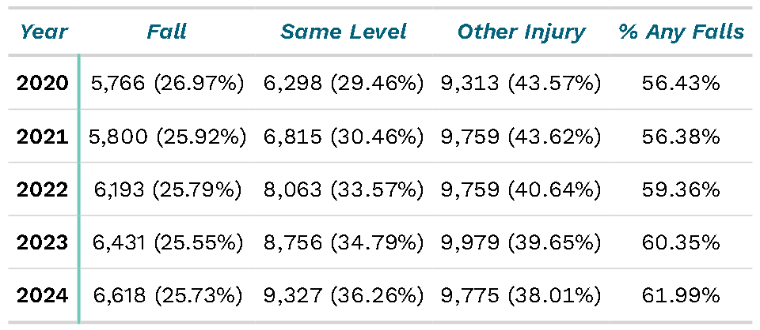

## What is the fall rate?

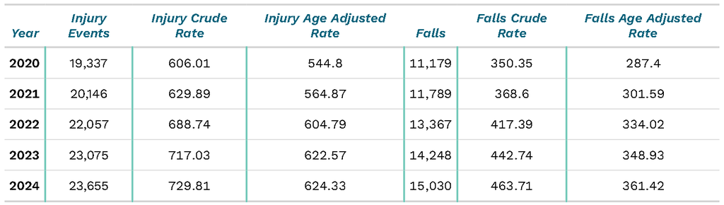

# Who falls the most?

In the upcoming slides, we will explore count data related to fall events by patient demographic characteristics.

## Age Groups

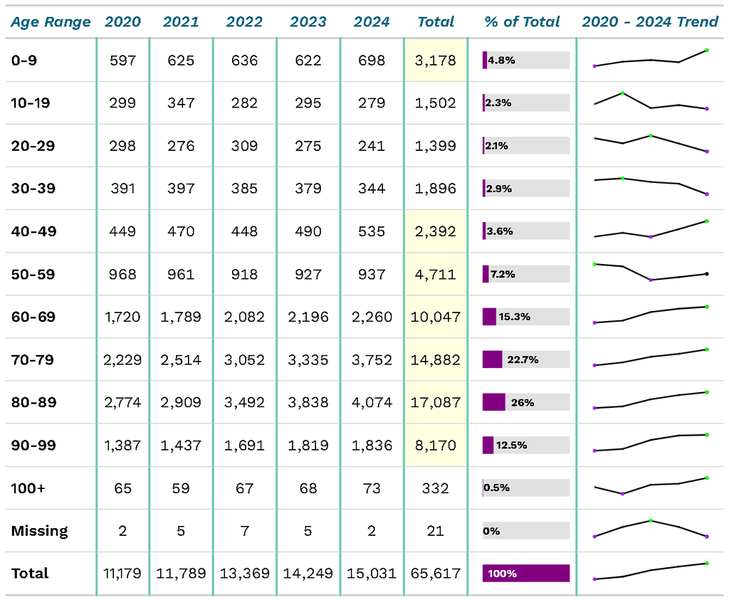

## Patient Sex

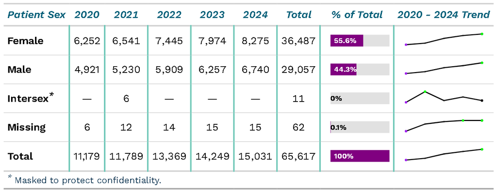

## Patient Race - All

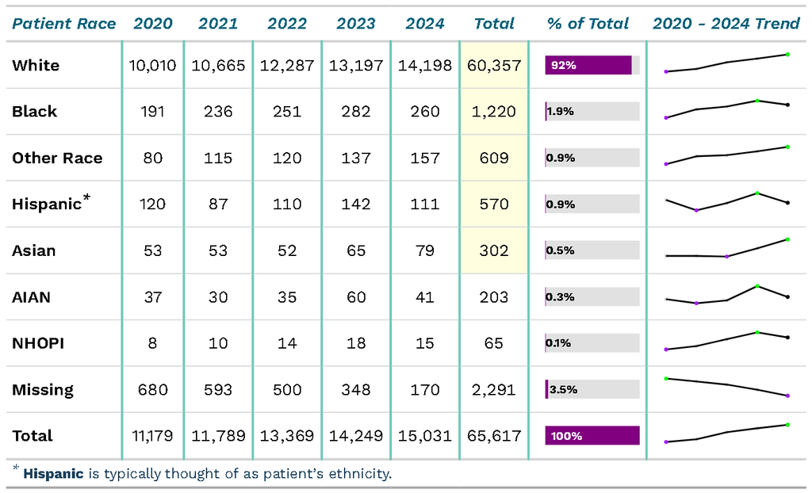

## Patient Race - Select

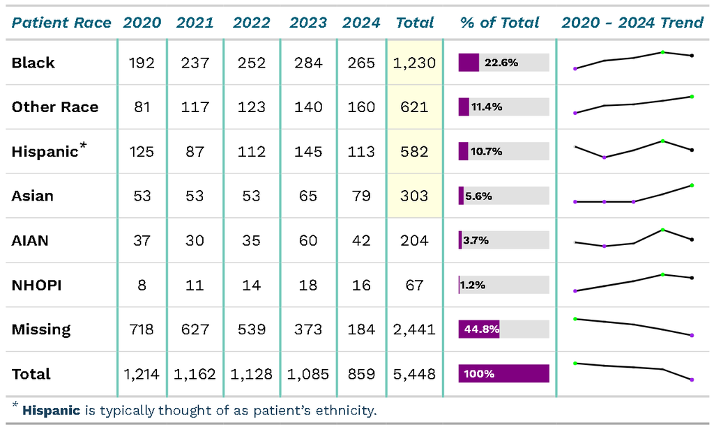

## Insurance

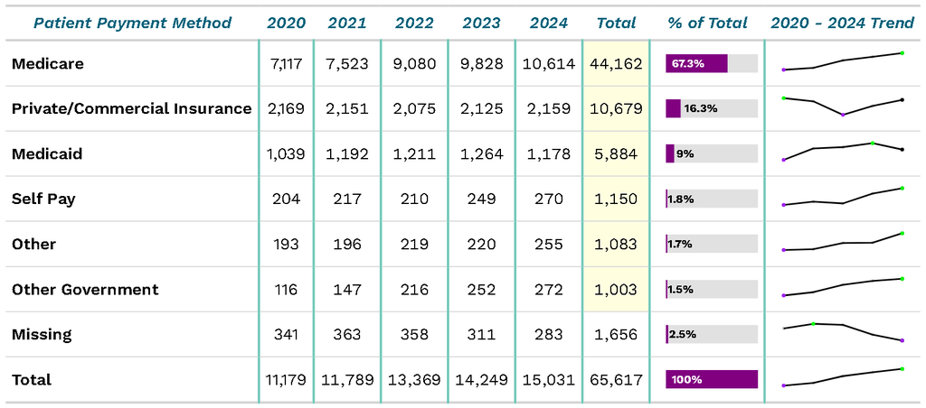

# Where do we fall?

[interactive chart not shown]

# Patient outcomes

Now, we will learn more about the morbidity and mortality related to falls in Iowa.

## Body regions affected

Falls disproportionately result in TBI.

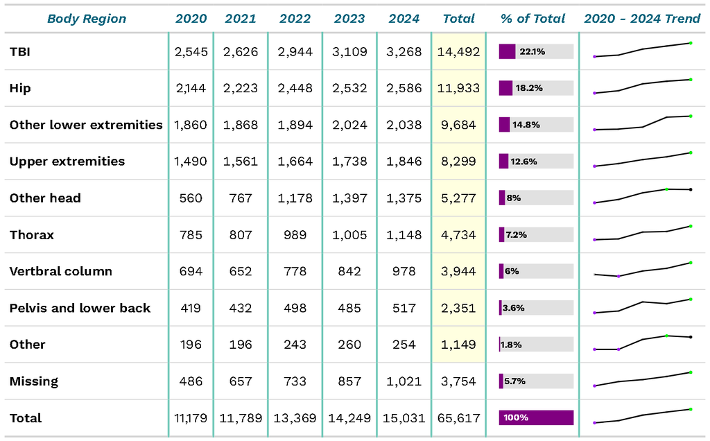

## Trauma Team Activations

We just saw how often severe injuries happen to fall patients how often do we activate the trauma team with falls compared to non falls?

## Trauma Team Activations

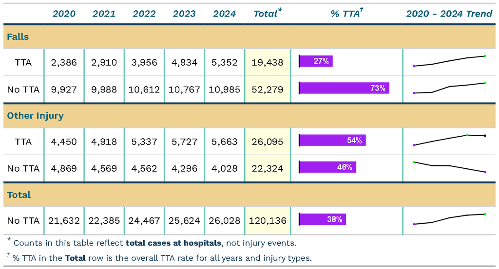

## Falls Injury Severity

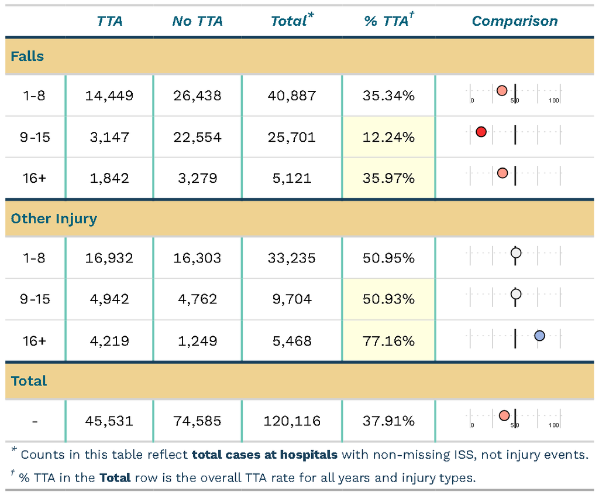

## Survival rate overall

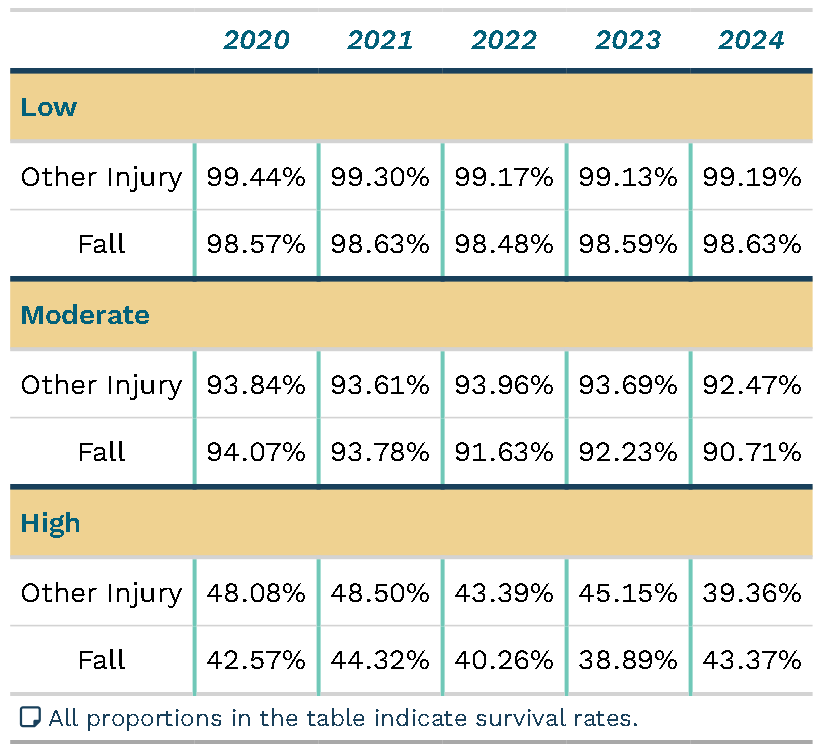

## Risk adjusted mortality

Falls at times have poorer outcomes than other injuries.

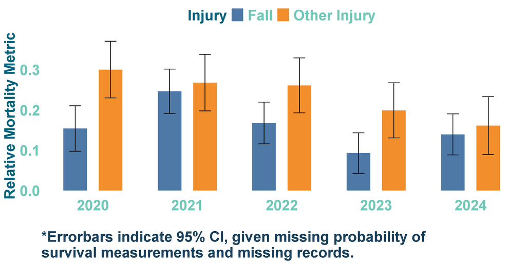

## Risk adjusted mortality, digging deeper

A deeper dive.

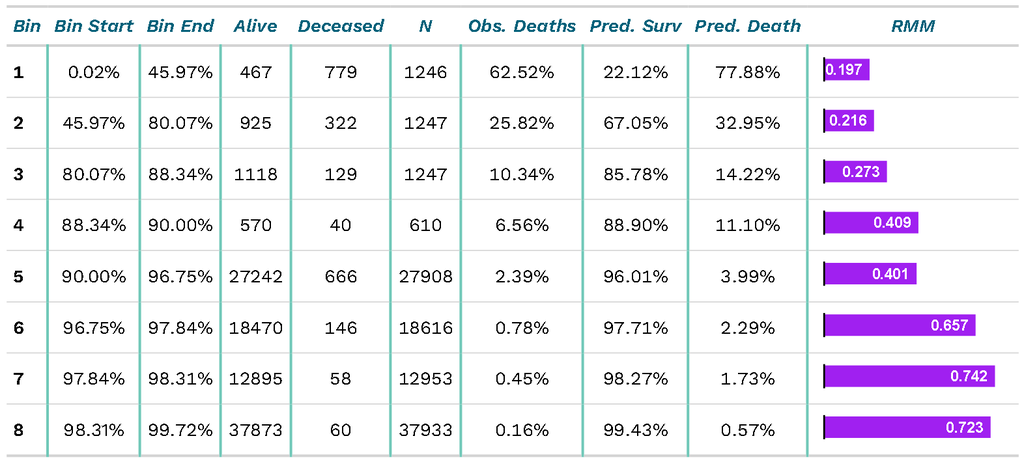

# A job well done

- From 2020-2024, we expected 2,146 deaths.
- We observed 1,374 deaths
- Overall, Iowa trauma centers saved 772 fall patients that were predicted to die from 2020-2024.

# Takeaways

# Takeaways (continued)

- Falls are not triaged as aggressively in trauma centers, and warrant more attention
- Apprx. 4% of the Iowa trauma patient population accounts for ~ 10% of all injury events
  - This is a group that gets injured frequently (**reinjury**), and is a prime target for prevention efforts.

# Analyses

At BEMTS, we have been hard at work creating open source software that benefits Iowans and other jurisdictions.

[GitHub Page](https://github.com/bemts-hhs/) [`{traumar}` package page](https://bemts-hhs.github.io/traumar/)

# Questions?

# Thanks!

- Nicolas Foss, Ed.D., MS
- Epidemiologist
- Bureau of Emergency Medical and Trauma Services
- Bureau of Health Statistics
- Division of Public Health > Iowa HHS
- C: 515.985.9627 || E: nicolas.foss at hhs.iowa.gov